# HW 3 Zilin Yin

This code may (or may not!) be helpful in your third assignment. Feel free to use it (or not).

## Setup

First, let's make sure this notebook works well in both python 2 and 3, import a few common modules, ensure MatplotLib plots figures inline and prepare a function to save the figures:

This section provides some initialization commands, which can simply be copied for assignments.

```python
# To support both python 2 and python 3
from __future__ import division, print_function, unicode_literals

# We need to import key libraries that we're going to use.
# For now this is just numpy, which is our linear algebra library
import numpy as np
```

Setting the random seed for code reproducibility.

```python
# to make this notebook's output stable across runs, we are going to see the random seed
np.random.seed(42)
```

Note that we have to reset the random seed *every* time we run an algorithm if we want the same results!

We also want to set up a plotting environment and make it look pretty. For those of you familiar with matlab, we will be using matplotlib which is fairly close in syntax and feel. It's not too far off from R either.

```python
# To plot pretty figures
import matplotlib.pyplot as plt
%matplotlib inline
# This command figures show up in the notebook.  It's a "magic" command...
# Typically, this now happens by default so it is often an unnecessary command, but is good for standardization.
plt.rcParams['axes.labelsize'] = 14
plt.rcParams['xtick.labelsize'] = 12
plt.rcParams['ytick.labelsize'] = 12
```

These commands will help us save figures; not going to go through them so much.

```python
# Where to save the figures
PROJECT_ROOT_DIR = "."
PROJECT_SAVE_DIR = "hw3"
```

```python
# makes the directory if it doesn't exist.
import os
if not (os.path.isdir(PROJECT_ROOT_DIR+'/'+PROJECT_SAVE_DIR)):
    print('Figure directory didn\'t exist, creating now.')
    os.mkdir(PROJECT_ROOT_DIR+'/'+PROJECT_SAVE_DIR)
else:
    print('Figure directory exists.')
```

```
Figure directory exists.
```

```python
# a simple defined helper function.
def savepdf(fig,name):
    fig.savefig(PROJECT_ROOT_DIR+'/'+PROJECT_SAVE_DIR+'/'+name+'.pdf')
```

## Problem 2

```python
import pandas as pd
```

HW 2, Problem 4

```python
ydf=pd.read_csv('hw2_hw2_problem_4_y_blind.csv')
y_blind=np.array(ydf.values[:,1],dtype=np.float64)

ydf=pd.read_csv('hw2_problem_4_y_blind_predicted.csv')
y_pred=np.array(ydf.values[:,1],dtype=np.float64)
```

```python
from sklearn.metrics import mean_squared_error

mean_squared_error(y_true=y_blind,y_pred=y_pred)
```

```
1.0851646136383457
```

### MSE is around 1.085, which is a reasonable value as it's smaller than 1.3

HW 2, Problem 5

```python
ydf=pd.read_csv('hw2_hw2_problem_5_y_blind.csv')
y_blind=np.array(ydf.values[:,1],dtype=np.float64)

ydf=pd.read_csv('hw2_problem_5_y_blind_predicted.csv')
y_pred=np.array(ydf.values[:,1],dtype=np.float64)
```

```python
from sklearn.metrics import roc_auc_score

roc_auc_score(y_blind, y_pred)
```

```
0.8224176646706587
```

### AUC is around 0.822, which is lower than expected. The reason of this is probably that when I randomly splited the data into training and validation set, the model fitted based on the them happens to predict bad on the blind dataset. Hence, I shall include more randomness when fitting the model like increasing the cross validation fold, such that the model could be more generalized, and may yields a better auc score on the blind data.

## Problem 3

```python
from sklearn.datasets import load_iris
```

```python
data=load_iris(return_X_y=False)

X = data['data']
y = data['target']
print(data.DESCR)
```

```
.. _iris_dataset:

Iris plants dataset
--------------------

**Data Set Characteristics:**

    :Number of Instances: 150 (50 in each of three classes)
    :Number of Attributes: 4 numeric, predictive attributes and the class
    :Attribute Information:
        - sepal length in cm
        - sepal width in cm
        - petal length in cm
        - petal width in cm
        - class:
                - Iris-Setosa
                - Iris-Versicolour
                - Iris-Virginica

    :Summary Statistics:

    ============== ==== ==== ======= ===== ====================
                    Min  Max   Mean    SD   Class Correlation
    ============== ==== ==== ======= ===== ====================
    sepal length:   4.3  7.9   5.84   0.83    0.7826
    sepal width:    2.0  4.4   3.05   0.43   -0.4194
    petal length:   1.0  6.9   3.76   1.76    0.9490  (high!)
    petal width:    0.1  2.5   1.20   0.76    0.9565  (high!)
    ============== ==== ==== ======= ===== ====================

    :Missing Attribute Values: None
    :Class Distribution: 33.3% for each of 3 classes.
    :Creator: R.A. Fisher
    :Donor: Michael Marshall (MARSHALL%PLU@io.arc.nasa.gov)
    :Date: July, 1988

The famous Iris database, first used by Sir R.A. Fisher. The dataset is taken
from Fisher's paper. Note that it's the same as in R, but not as in the UCI
Machine Learning Repository, which has two wrong data points.

```

[output cut: 8 more lines]

```

   - Fisher, R.A. "The use of multiple measurements in taxonomic problems"
     Annual Eugenics, 7, Part II, 179-188 (1936); also in "Contributions to
     Mathematical Statistics" (John Wiley, NY, 1950).
   - Duda, R.O., & Hart, P.E. (1973) Pattern Classification and Scene Analysis.
     (Q327.D83) John Wiley & Sons.  ISBN 0-471-22361-1.  See page 218.
   - Dasarathy, B.V. (1980) "Nosing Around the Neighborhood: A New System
     Structure and Classification Rule for Recognition in Partially Exposed
     Environments".  IEEE Transactions on Pattern Analysis and Machine
     Intelligence, Vol. PAMI-2, No. 1, 67-71.
   - Gates, G.W. (1972) "The Reduced Nearest Neighbor Rule".  IEEE Transactions
     on Information Theory, May 1972, 431-433.
   - See also: 1988 MLC Proceedings, 54-64.  Cheeseman et al"s AUTOCLASS II
     conceptual clustering system finds 3 classes in the data.
   - Many, many more ...
```

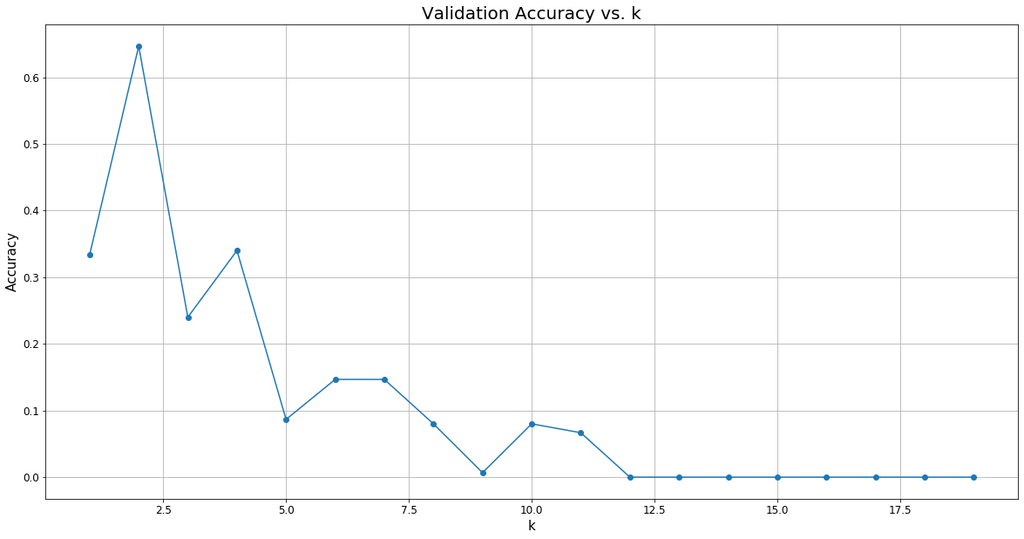

```python
from sklearn import cluster
import matplotlib.pyplot as plt
from sklearn.metrics import accuracy_score
import numpy as np
from sklearn.metrics import mean_squared_error

centers = []
labels = []
inertia = []
ks = np.arange(20)
for k in ks:
    if k == 0:
        continue
    kmeans_clf = cluster.KMeans(n_clusters=k, max_iter=1000, random_state = 42)
    kmeans_clf.fit(X)
    #print(kmeans_clf.cluster_centers_)
    #print(kmeans_clf.labels_)
    labels.append(kmeans_clf.labels_)
    centers.append(kmeans_clf.cluster_centers_)
    inertia.append(kmeans_clf.inertia_ / 150)
labels = np.array(labels)
acc = []
for label in labels:
    acc.append(accuracy_score(y_true = y, y_pred = label))

plt.figure(figsize = (20, 10))
plt.plot(ks[1:], acc, 'o-')
plt.grid('on')
plt.title('Validation Accuracy vs. k', fontsize = 20)
plt.xlabel('k', fontsize = 15)
plt.ylabel('Accuracy', fontsize = 15)
plt.show()
```

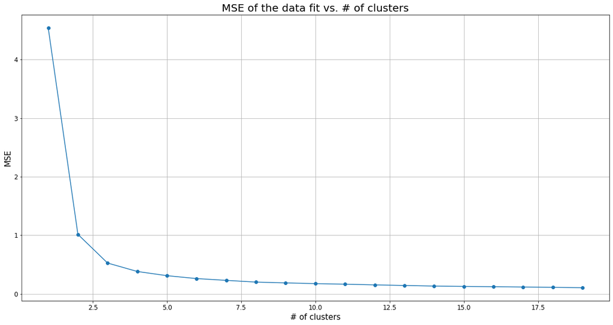

```python
plt.figure(figsize = (20, 10))
plt.plot(ks[1:20], inertia, 'o-')
plt.grid('on')
plt.title('MSE of the data fit vs. # of clusters', fontsize = 20)
plt.xlabel('# of clusters', fontsize = 15)
plt.ylabel('MSE', fontsize = 15)
plt.show()
```

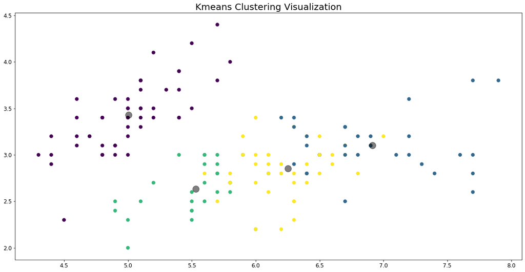

```python
from sklearn import decomposition

kmeans_clf = cluster.KMeans(n_clusters=4, max_iter=1000, random_state = 42)
kmeans_clf.fit(X)
y_kmeans = kmeans_clf.predict(X)
plt.figure(figsize = (20, 10))
plt.scatter(X[:, 0], X[:, 1], c=y_kmeans, s=50, cmap='viridis')

centers = kmeans_clf.cluster_centers_
plt.scatter(centers[:, 0], centers[:, 1], c='black', s=200, alpha=0.5)
plt.title('Kmeans Clustering Visualization', fontsize = 20)
plt.show()
```

### The best number of clusters is 2, since it has the highest accuracy score. By broadly looking at the plot above, we can see that starting from # of clusteres = 1, the accuracy score has a general trend to decrease with increasing # of clusters.

### However, this is a unsupervised learning problem, which means we should ignore accuracy because in real life we would have that for reference. Hence, for the final implementation of kmeans clustering, I choose the number of clusters of 4 because based on the mse of the data fit vs. # of clusters above, the turning point of the trending seems to occur around 4.

Second dataset on physiological data

```
   Unnamed: 0          0          1          2          3          4  \
0           0  -0.023620  21.944173  18.960183   3.132551  13.979178
1           1  20.902363  23.255379  24.690817  13.554893   3.354168
2           2  31.903238  42.158857  32.250549  13.958497   8.553392
3           3  20.666917   8.500994  -8.439214  -4.256666  16.442294
4           4  -6.796520  13.262457  21.554241   6.104422   4.008318

           5          6          7          8  ...         30         31  \
0  28.367241  18.723381  25.511008  55.558249  ...  38.387962  29.178772
1  -3.854402 -23.724008 -34.097319 -12.510786  ... -25.981366 -11.347417
2   9.613060   1.406107 -11.156904 -22.648421  ...   8.903100  10.780929
3  26.708693  30.041928  42.532841  38.945807  ...   0.081823  -6.986620
4  15.458469   5.429862  -4.315298  13.718439  ... -15.773499   5.777321

          32         33         34         35         36         37  \
0   7.860111  -4.507771  -8.347115  -3.715087   3.333201  -1.117069
1 -13.985121 -10.040395  -2.411964  -6.380681  -7.824229   1.062964
2  18.719637  25.413572  17.148254  -9.457989 -33.547526 -32.628208
3  -3.831725  -4.879602 -19.539793 -26.860171 -16.436037  -2.367696
4  14.570835  10.886716   5.612393   1.686606  -8.923928 -27.328744

          38         39
0  -7.101238   1.415413
1   2.673387   1.211577
2 -14.685991  -4.942856
3   4.344424  -1.190937
4 -37.031738 -27.452618

[5 rows x 41 columns]
```

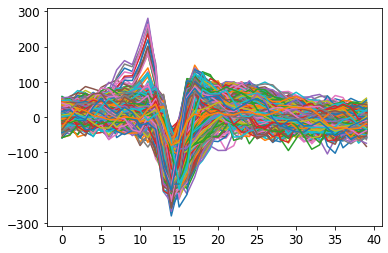

```
(2242, 40)
```

```python
import pandas as pd

Xdf=pd.read_csv('hw3_hw3_physio.csv')
X=np.array(Xdf.values[:,1:],dtype=np.float64)
print(Xdf.head())
fig=plt.figure()
plt.plot(X.T)
plt.show()
print(X.shape)
```

```python
labels = []
centers = []
inertia = []
ks = np.arange(50)
for k in ks:
    if k == 0:
        continue
    kmeans_clf = cluster.KMeans(n_clusters=k, max_iter=100)
    kmeans_clf.fit(X)
    labels.append(kmeans_clf.labels_)
    centers.append(kmeans_clf.cluster_centers_)
    inertia.append(kmeans_clf.inertia_ / 2242)
labels = np.array(labels)
```

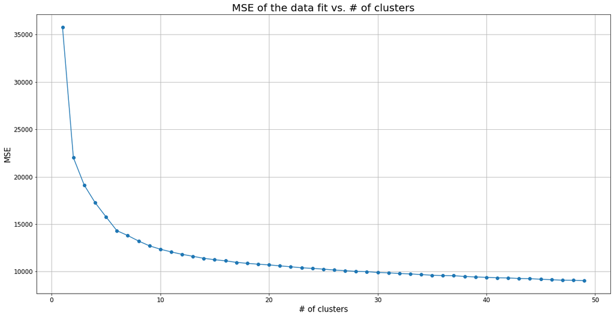

```python
plt.figure(figsize = (20, 10))
plt.plot(ks[1:50], inertia, 'o-')
plt.grid('on')
plt.title('MSE of the data fit vs. # of clusters', fontsize = 20)
plt.xlabel('# of clusters', fontsize = 15)
plt.ylabel('MSE', fontsize = 15)
plt.show()
```

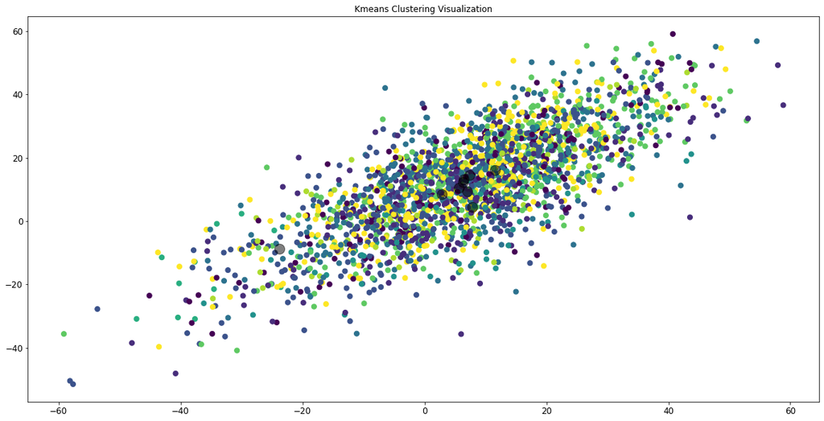

```python
kmeans_clf = cluster.KMeans(n_clusters=9, max_iter=1000, random_state = 42)
kmeans_clf.fit(X)
y_kmeans = kmeans_clf.predict(X)
plt.figure(figsize = (20, 10))
plt.scatter(X[:, 0], X[:, 1], c=y_kmeans, s=50, cmap='viridis')

centers = kmeans_clf.cluster_centers_
plt.scatter(centers[:, 0], centers[:, 1], c='black', s=200, alpha=0.5)
plt.title('Kmeans Clustering Visualization')
plt.show()
```

## Problem 4

Load the dataset (same as problem 3)

```python
import pandas as pd
import numpy as np
from sklearn import cluster

Xdf=pd.read_csv('hw3_hw3_physio.csv')
X=np.array(Xdf.values[:,1:],dtype=np.float64)
print(X.shape)
```

```
(2242, 40)
```

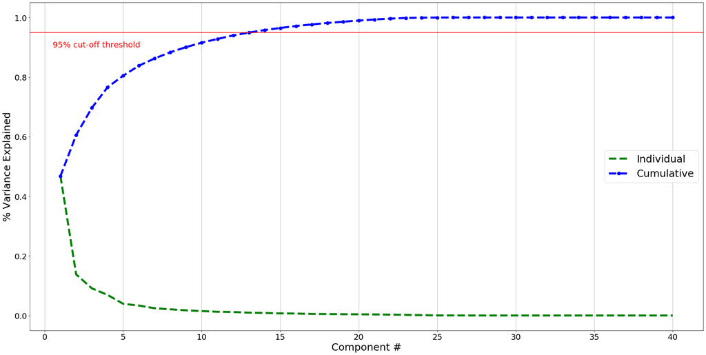

```python
#visualizing components' explained variance

from mpl_toolkits.axes_grid1 import make_axes_locatable
import matplotlib.pyplot as plt
from sklearn import decomposition

n_components = 40
pca=decomposition.PCA(n_components=n_components)
pca.fit(X)
pca.explained_variance_ratio_

plt.figure(figsize=(30,15))
plt.plot(np.arange(1,41),pca.explained_variance_ratio_[:40],linestyle='--',color='green',lw=5,ms=8,label='Individual')
plt.plot(np.arange(1,41),np.cumsum(pca.explained_variance_ratio_[:40]),marker='o',color='b',linestyle='--',lw=5,ms=8, label='Cumulative')
plt.axhline(y=0.95, color='r', linestyle='-')
plt.text(0.5, 0.9, '95% cut-off threshold', color = 'red', fontsize=20)
plt.legend(fontsize = 25)
plt.xlabel('Component #', fontsize = 25)
plt.ylabel('% Variance Explained', fontsize = 25)
plt.xticks(size =20)
plt.yticks(size =20)
plt.grid(axis='x')
plt.show()
```

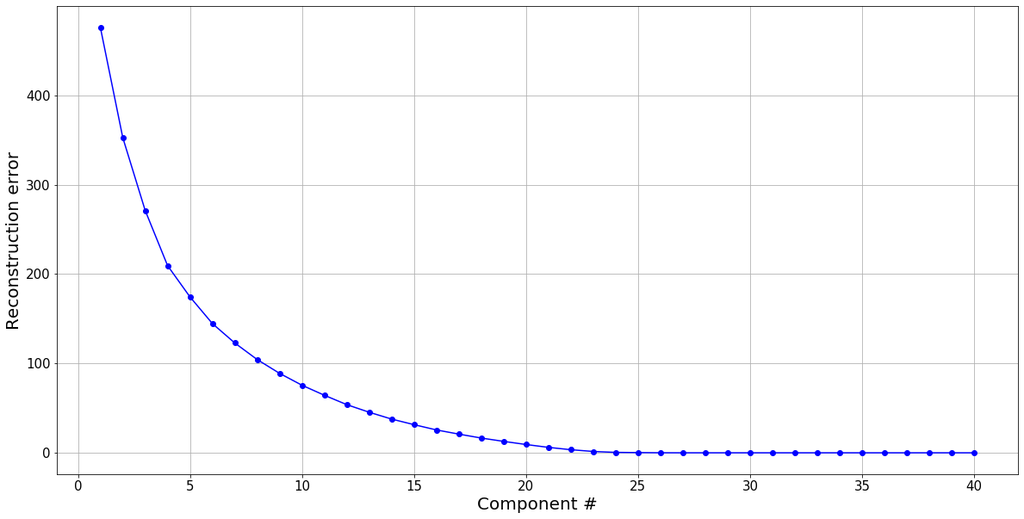

```python
#visualizing reconstruction loss

losses = []
components = np.arange(1, 41)
for n_components in components:
    pca=decomposition.PCA(n_components=n_components)
    X_re = pca.fit_transform(X)
    proj = pca.inverse_transform(X_re)
    loss = ((X - proj) ** 2).mean()
    losses.append(loss)
losses = np.array(losses)

plt.figure(figsize = (20, 10))
plt.plot(components, losses, 'o-', color='b')
plt.xlabel('Component #', fontsize = 20)
plt.ylabel('Reconstruction error', fontsize = 20)
plt.xticks(size =15)
plt.yticks(size =15)
plt.grid('on')
plt.show()
```

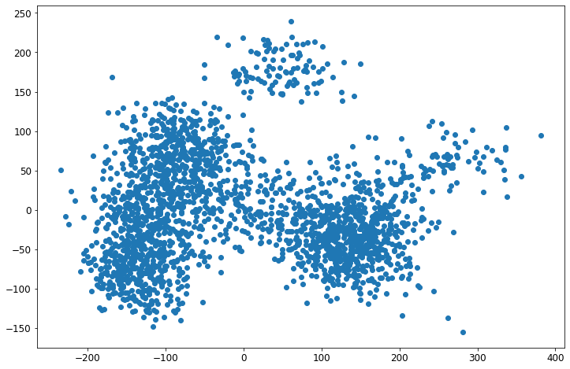

```python
#embedding it in the top 2 principal components

n_components = 2
pca=decomposition.PCA(n_components=n_components)
X_re = pca.fit_transform(X)
x_ax = X_re[:, 0]
y_ax = X_re[:, 1]

plt.figure(figsize = (12, 8))
plt.plot(x_ax, y_ax, 'o')
plt.show()
```

### We would generally want a explained variance of 95%. Therefore, # of component = 10~15 would be a reasonable value

## Problem 5

```python
import numpy as np
import pandas as pd

Xdf=pd.read_csv('hw3_hw3_problem_5_X.csv')
ydf=pd.read_csv('hw3_hw3_problem_5_y.csv')
Xdf_blind=pd.read_csv('hw3_hw3_problem_5_X_blind.csv')
X=np.array(Xdf.values[:,1:],dtype=np.float64)
y=np.array(ydf.values[:,1],dtype=np.float64)
X_blind=np.array(Xdf_blind.values[:,1:],dtype=np.float64)
```

```python
#Normalizinig Dataset

from sklearn import preprocessing

std_scaler = preprocessing.StandardScaler()
X_re = std_scaler.fit_transform(X)
```

```python
from sklearn import datasets, model_selection, linear_model, metrics

X_train,X_valid,y_train,y_valid=\
    model_selection.train_test_split(X,y,random_state=42)
```

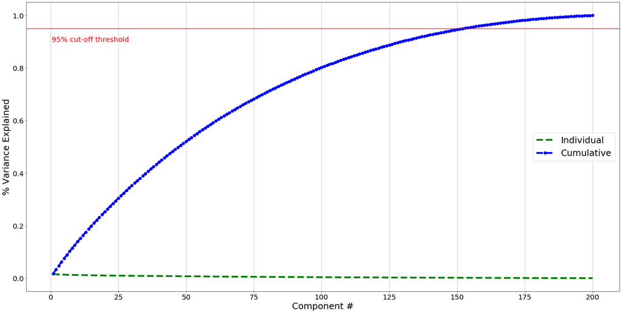

```python
#Visualizing the amount of components to use - rule of thumb

from mpl_toolkits.axes_grid1 import make_axes_locatable
import matplotlib.pyplot as plt
from sklearn import decomposition

n_components = 200
pca=decomposition.PCA(n_components=n_components)
pca.fit(X_re, y)
pca.explained_variance_ratio_

plt.figure(figsize=(30,15))
plt.plot(np.arange(1,201),pca.explained_variance_ratio_[:200],linestyle='--',color='green',lw=5,ms=8,label='Individual')
plt.plot(np.arange(1,201),np.cumsum(pca.explained_variance_ratio_[:200]),marker='o',color='b',linestyle='--',lw=5,ms=8, label='Cumulative')
plt.axhline(y=0.95, color='r', linestyle='-')
plt.text(0.5, 0.9, '95% cut-off threshold', color = 'red', fontsize=20)
plt.legend(fontsize = 25)
plt.xlabel('Component #', fontsize = 25)
plt.ylabel('% Variance Explained', fontsize = 25)
plt.xticks(size =20)
plt.yticks(size =20)
plt.grid(axis='x')
plt.show()
```

### Based on rule of thumb, a good # of component would be around 150

```python
#Strategy1: Tuning parameters based on rule of thumb

from sklearn import decomposition
from sklearn import pipeline
from sklearn import svm
from sklearn.model_selection import GridSearchCV
import numpy as np
from sklearn.model_selection import StratifiedShuffleSplit

n_components = 150
C = [0.0001, 0.005, 0.001, 0.01, 0.1, 1, 5, 10, 100]
gamma = [0.001, 0.005, 0.01, 0.05, 0.1, 1]

pca=decomposition.PCA(n_components = n_components)
reg=svm.SVC(kernel='rbf')
pipe = pipeline.Pipeline([('pca',pca), ('reg',reg)])
#reg.get_params().keys()
cv = StratifiedShuffleSplit(n_splits=5, test_size=0.2, random_state=42)
estimator_acc = GridSearchCV(pipe,
                         dict(reg__C=C,
                              reg__gamma=gamma), cv=cv, scoring = 'accuracy')
estimator_f1 = GridSearchCV(pipe,
                         dict(reg__C=C,
                              reg__gamma=gamma), cv=cv, scoring = 'f1_micro')
estimator_roc_auc = GridSearchCV(pipe,
                         dict(reg__C=C,
                              reg__gamma=gamma), cv=cv, scoring = 'roc_auc')

estimator_acc.fit(X_re, y)
print("The best parameters are %s with a score of %0.2f with accuracy_score"
      % (estimator_acc.best_params_, estimator_acc.best_score_))
estimator_f1.fit(X_re, y)
print("The best parameters are %s with a score of %0.2f with f1_score"
      % (estimator_f1.best_params_, estimator_f1.best_score_))
estimator_roc_auc.fit(X_re, y)
print("The best parameters are %s with a score of %0.2f with roc_auc"
      % (estimator_roc_auc.best_params_, estimator_roc_auc.best_score_))
```

```
The best parameters are {'reg__C': 1, 'reg__gamma': 0.005} with a score of 0.72 with accuracy_score
The best parameters are {'reg__C': 1, 'reg__gamma': 0.005} with a score of 0.72 with f1_score
The best parameters are {'reg__C': 0.0001, 'reg__gamma': 0.01} with a score of 0.76 with roc_auc
```

### Based on rule of thumb, we take # of components to be 150, and tune the other two parameters, the result is shown above.

```python
#Strategy2: Tuning three parameters all at once

n_components = [10, 50, 110, 120, 130, 135, 140, 145, 150, 155, 160, 170]
C = [0.0001, 0.005, 0.001, 0.01, 0.1, 1, 5, 10, 100]
gamma = [0.001, 0.005, 0.01, 0.05, 0.1, 1]

pca=decomposition.PCA()
reg=svm.SVC(kernel='rbf')
pipe = pipeline.Pipeline([('pca',pca), ('reg',reg)])
#reg.get_params().keys()
cv = StratifiedShuffleSplit(n_splits=5, test_size=0.2, random_state=42)
estimator_acc = GridSearchCV(pipe,
                         dict(pca__n_components=n_components,
                              reg__C=C,
                              reg__gamma=gamma), cv=cv, scoring = 'accuracy')
estimator_f1 = GridSearchCV(pipe,
                         dict(pca__n_components=n_components,
                              reg__C=C,
                              reg__gamma=gamma), cv=cv, scoring = 'f1_micro')
estimator_roc_auc = GridSearchCV(pipe,
                         dict(pca__n_components=n_components,
                              reg__C=C,
                              reg__gamma=gamma), cv=cv, scoring = 'roc_auc')

estimator_acc.fit(X_re, y)
print("The best parameters are %s with a score of %0.2f with accuracy_score"
      % (estimator_acc.best_params_, estimator_acc.best_score_))
estimator_f1.fit(X_re, y)
print("The best parameters are %s with a score of %0.2f with f1_score"
      % (estimator_f1.best_params_, estimator_f1.best_score_))
estimator_roc_auc.fit(X_re, y)
print("The best parameters are %s with a score of %0.2f with roc_auc"
      % (estimator_roc_auc.best_params_, estimator_roc_auc.best_score_))
```

```
The best parameters are {'pca__n_components': 150, 'reg__C': 1, 'reg__gamma': 0.005} with a score of 0.72 with accuracy_score
The best parameters are {'pca__n_components': 150, 'reg__C': 1, 'reg__gamma': 0.005} with a score of 0.72 with f1_score
The best parameters are {'pca__n_components': 110, 'reg__C': 1, 'reg__gamma': 0.005} with a score of 0.77 with roc_auc
```

### No based on rule of thumb, tune all three parameters at once. Based on the computations shown above, we see that there are only slight difference between the scores computed based on f1, accuracy and roc_auc scoring metrics.

### We could draw the assumption that if we predict in terms of AUC on the blind data, the prediction score would be around 0.77 or 77%.

```python
#Doing the final prediction
n_components = 110
gamma = 0.005
C = 1

std_scaler = preprocessing.StandardScaler()
X_blind_re = std_scaler.fit_transform(X_blind)
X_re = std_scaler.fit_transform(X)
pca=decomposition.PCA(n_components=n_components)
X_blind_re_re = pca.fit_transform(X_blind_re)
X_re_re = pca.fit_transform(X_re)
reg=svm.SVC(kernel='rbf', gamma=gamma, C=C)
reg.fit(X_re_re, y)
y_blind = reg.predict(X_blind_re_re)
print(y_blind)
```

```
[0. 0. 0. 0. 1. 1. 1. 1. 1. 1. 0. 1. 0. 0. 0. 0. 1. 1. 0. 1. 1. 0. 0. 0.
 0. 0. 0. 0. 0. 1. 1. 1. 1. 1. 0. 1. 1. 1. 0. 1. 1. 1. 0. 1. 0. 1. 0. 0.
 0. 0. 0. 0. 1. 1. 0. 0. 1. 0. 1. 0. 0. 1. 0. 0. 1. 0. 0. 0. 1. 1. 0. 0.
 1. 0. 1. 0. 0. 1. 0. 0. 0. 1. 0. 1. 1. 0. 0. 1. 1. 1. 0. 1. 1. 0. 0. 1.
 1. 0. 0. 1. 1. 1. 0. 1. 1. 0. 0. 0. 1. 1. 0. 0. 0. 0. 0. 1. 0. 0. 0. 0.
 1. 0. 0. 1. 0.]
```